# Lab Assignment: Chapter 18 - Basic Statistics

Michael Beebe

```r
library(ggplot2)
library(GGally)
library(MASS)
library(reshape2)
library(plyr)
library(dplyr)
```

## 1. Summary Stastics

Create a variable - stats - and store a random sample of 100 numbers between 100 and 200. Use replace=TRUE

```r
stats <- sample(x = 100:200, size = 100, replace = TRUE)
head(stats)
```

```
## [1] 134 160 164 116 185 198
```

Calculate the mean

```r
mean(stats)
```

```
## [1] 148.77
```

Calculate the variance (2 ways)

```r
sum((stats - mean(stats))^2) / (length(stats) - 1)
```

```
## [1] 819.6132
```

```r
var(stats)
```

```
## [1] 819.6132
```

Calculate the standard deviation (2 ways)

```r
sqrt(var(stats))
```

```
## [1] 28.62889
```

```r
sd(stats)
```

```
## [1] 28.62889
```

Display the summary statistics

```r
summary(stats)
```

```
##    Min. 1st Qu.  Median    Mean 3rd Qu.    Max.
##   101.0   125.5   147.0   148.8   175.0   198.0
```

Display the 1st and 3rd quartiles in a different way than the summary statistics

```r
quantile(x = stats, probs = c(.25, .75))
```

```
##   25%   75%
## 125.5 175.0
```

A student’s grades are the following: quiz 1= 78, quiz 2 = 74, quiz 3 = 78, quiz 4 = 76, midterm = 68, and final = 90. The quizzes are weighted at 1/8 of the final grade and the exams are weighted at 1/4.

```r
grades <- c(78, 74, 78, 76, 68, 90)
weights <- c(1/8, 1/8, 1/8, 1/8, 1/4, 1/4)
```

- Display the mean.

```r
mean(grades)
```

```
## [1] 77.33333
```

Display the weighted mean.

```r
weighted.mean(x = grades, w = weights)
```

```
## [1] 77.75
```

## 2. Correlation and Covariance

Using the Old Faithful data, store the waiting time in a variable and the eruption duration in another

```r
wait <- faithful$waiting
duration <- faithful$eruptions
```

Find the correlation coefficient of eruption duration and waiting time in the data set faithful.

```r
cor(wait, duration)
```

```
## [1] 0.9008112
```

```r
cor(faithful)
```

```
##           eruptions   waiting
## eruptions 1.0000000 0.9008112
## waiting   0.9008112 1.0000000
```

Observe if there is any linear relationship between the variables.

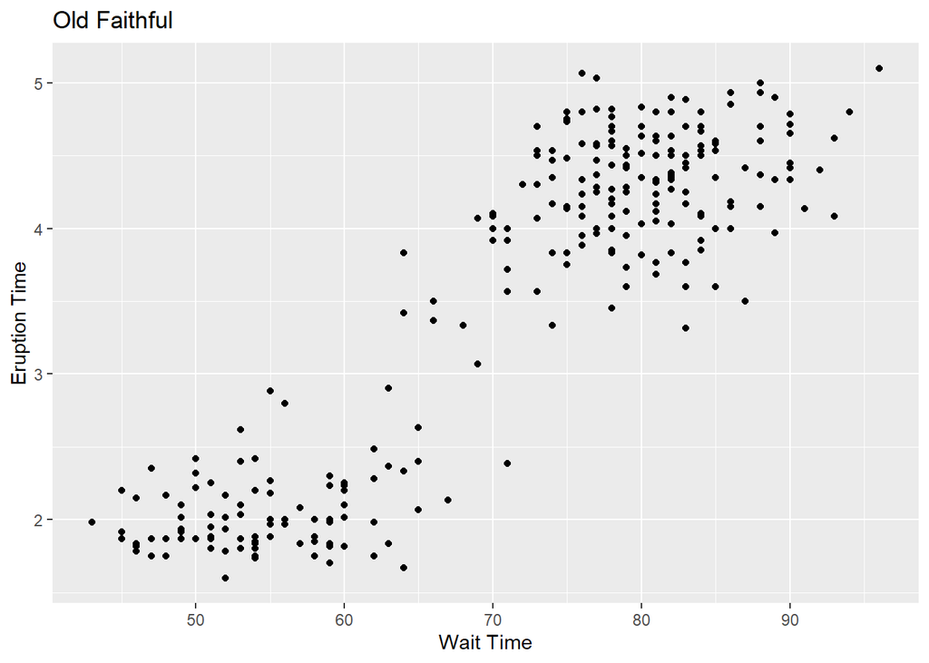

```r
ggplot(data.frame(x=wait, y=duration), aes(x=x, y=y)) +
  geom_point() +
  labs(x ="Wait Time", y = "Eruption Time", title = "Old Faithful")
```

- We can see that there is very much so a linear correlation between wait time between eruptions and the duration of the eruption.

Using the same variables find the covariance, and analyze the results

```r
cov(wait, duration)
```

```
## [1] 13.97781
```

```r
cov(faithful)
```

```
##           eruptions   waiting
## eruptions  1.302728  13.97781
## waiting   13.977808 184.82331
```

Use the cor function on a matrix to evaluate the faithful data.

```r
mat <- cbind(wait, duration)
cor(mat)
```

```
##               wait  duration
## wait     1.0000000 0.9008112
## duration 0.9008112 1.0000000
```

Graph the Old Faithful data

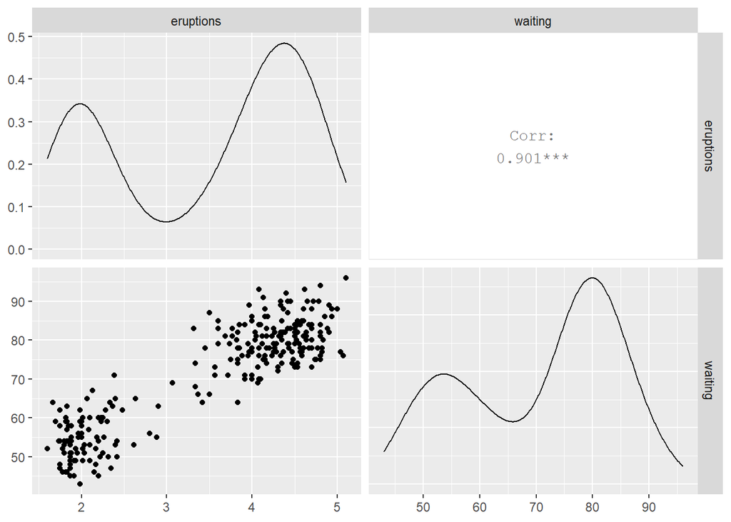

```r
ggpairs(faithful)
```

## 3. T-Tests

Use the built-in data set named immer, which contains data on the barley yield in years 1931 and 1932 of a field.

```r
head(immer)
```

```
##   Loc Var    Y1    Y2
## 1  UF   M  81.0  80.7
## 2  UF   S 105.4  82.3
## 3  UF   V 119.7  80.4
## 4  UF   T 109.7  87.2
## 5  UF   P  98.3  84.2
## 6   W   M 146.6 100.4
```

The data follows the normal distribution. Find the 95% confidence interval estimate of the difference between the mean barley yields.

```r
t.test(immer$Y1, immer$Y2, paired = TRUE, conf.level = 0.95)
```

```
##
##  Paired t-test
##
## data:  immer$Y1 and immer$Y2
## t = 3.324, df = 29, p-value = 0.002413
## alternative hypothesis: true difference in means is not equal to 0
## 95 percent confidence interval:
##   6.121954 25.704713
## sample estimates:
## mean of the differences
##                15.91333
```

Analyze the results

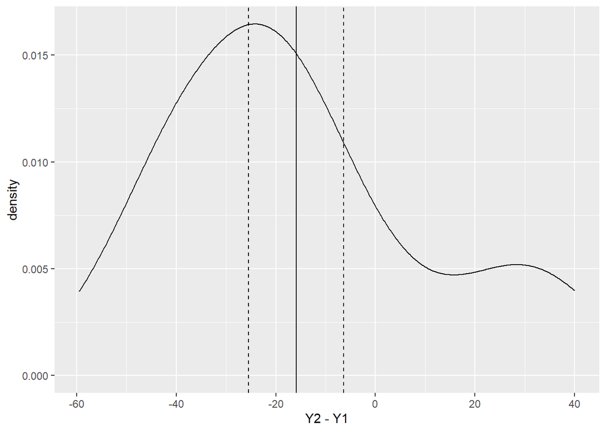

```r
yieldDiff <- immer$Y2 - immer$Y1

ggplot(immer, aes(x=Y2 - Y1)) +
  geom_density() +
  geom_vline(xintercept = mean(yieldDiff)) +
  geom_vline(xintercept = mean(yieldDiff) + 2*c(-1,1) * sd(yieldDiff) / sqrt(nrow(immer)), linetype=2)
```

## 4. ANOVA

Complete the Analysis of Variance for the TIPS data

```r
data(tips, package = "reshape2")
head(tips)
```

```
##   total_bill  tip    sex smoker day   time size
## 1      16.99 1.01 Female     No Sun Dinner    2
## 2      10.34 1.66   Male     No Sun Dinner    3
## 3      21.01 3.50   Male     No Sun Dinner    3
## 4      23.68 3.31   Male     No Sun Dinner    2
## 5      24.59 3.61 Female     No Sun Dinner    4
## 6      25.29 4.71   Male     No Sun Dinner    4
```

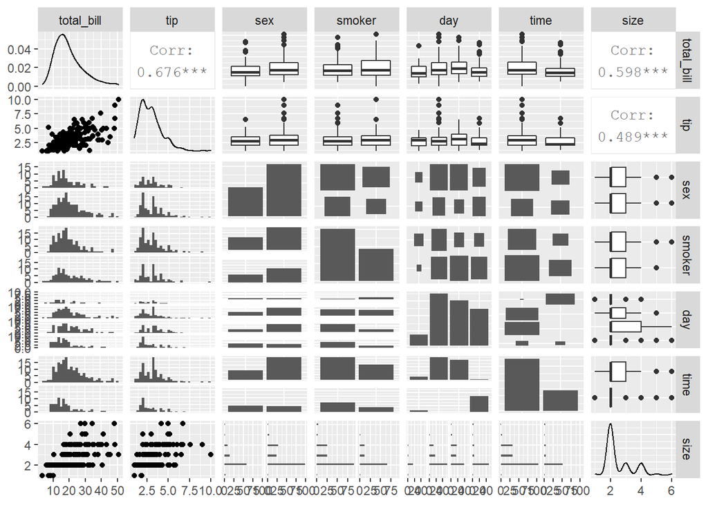

```r
ggpairs(tips)
```

```r
tipAnova <- aov(tip ~ day - 1, tips)
tipIntercept <- aov(tip ~ day, tips)
```

```r
tipAnova$coefficients
```

```
##   dayFri   daySat   daySun  dayThur
## 2.734737 2.993103 3.255132 2.771452
```

```r
tipIntercept$coefficients
```

```
## (Intercept)      daySat      daySun     dayThur
##  2.73473684  0.25836661  0.52039474  0.03671477
```

```r
summary(tipAnova)
```

```
##            Df Sum Sq Mean Sq F value Pr(>F)
## day         4 2203.0   550.8   290.1 <2e-16 ***
## Residuals 240  455.7     1.9
## ---
## Signif. codes:  0 '***' 0.001 '**' 0.01 '*' 0.05 '.' 0.1 ' ' 1
```

Analyze the p-values for each set of summary data.

```r
tipsByDay <- ddply(
  tips,
  "day",
  summarize,
  tip.mean=mean(tip),
  Length=NROW(tip),
  tip.sd=sd(tip),
  tfrac=qt(p=.90, df=Length-1),
  Lower=tip.mean - tfrac*tip.sd/sqrt(Length),
  Upper=tip.mean + tfrac*tip.sd/sqrt(Length)
)
tipsByDay
```

```
##    day tip.mean Length   tip.sd    tfrac    Lower    Upper
## 1  Fri 2.734737     19 1.019577 1.330391 2.423549 3.045925
## 2  Sat 2.993103     87 1.631014 1.291473 2.767272 3.218934
## 3  Sun 3.255132     76 1.234880 1.292941 3.071986 3.438277
## 4 Thur 2.771452     62 1.240223 1.295585 2.567386 2.975517
```

Plot the dataset.

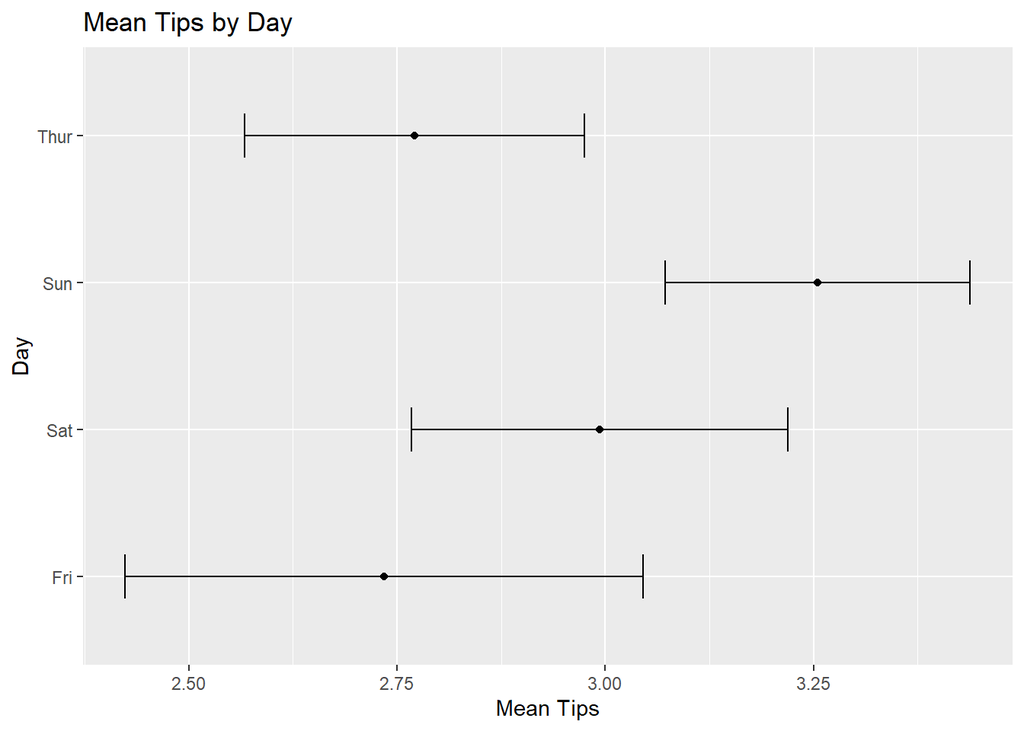

```r
ggplot(tipsByDay, aes(x=tip.mean, y=day)) +
  geom_point() +
  geom_errorbarh(aes(xmin=Lower, xmax=Upper), height=.3) +
  labs(x="Mean Tips", y="Day", title = {"Mean Tips by Day"})
```

Complete the Analysis of Variance for the Old Faithful data.

```r
head(faithful)
```

```
##   eruptions waiting
## 1     3.600      79
## 2     1.800      54
## 3     3.333      74
## 4     2.283      62
## 5     4.533      85
## 6     2.883      55
```

```r
faithfulAnova <- aov(eruptions ~ waiting -1, faithful)
faithfulIntercept <- aov(eruptions ~ waiting, faithful)
```

```r
faithfulAnova$coefficients
```

```
##    waiting
## 0.05012919
```

```r
faithfulIntercept$coefficients
```

```
## (Intercept)     waiting
## -1.87401599  0.07562795
```

```r
summary(faithfulAnova)
```

```
##            Df Sum Sq Mean Sq F value Pr(>F)
## waiting     1   3561    3561    9621 <2e-16 ***
## Residuals 271    100       0
## ---
## Signif. codes:  0 '***' 0.001 '**' 0.01 '*' 0.05 '.' 0.1 ' ' 1
```

Analyze the p-values for each set of summary data.

```r
eruptionsByWait <- ddply(
  faithful,
  "waiting",
  summarize,
  eruptions.mean=mean(eruptions),
  Length=NROW(eruptions),
  eruptions.sd=sd(eruptions),
  tfrac=qt(p=.90, df=Length-1),
  Lower=eruptions.mean - tfrac*eruptions.sd/sqrt(Length),
  Upper=eruptions.mean + tfrac*eruptions.sd/sqrt(Length)
)
head(eruptionsByWait)
```

```
##   waiting eruptions.mean Length eruptions.sd    tfrac    Lower    Upper
## 1      43       1.983000      1           NA      NaN      NaN      NaN
## 2      45       1.994667      3   0.17957264 1.885618 1.799173 2.190161
## 3      46       1.883200      5   0.15053637 1.533206 1.779982 1.986418
## 4      47       1.929250      4   0.28587104 1.637744 1.695158 2.163342
## 5      48       1.928000      3   0.21508835 1.885618 1.693841 2.162159
## 6      49       1.966800      5   0.09198478 1.533206 1.903729 2.029871
```

Plot the dataset.

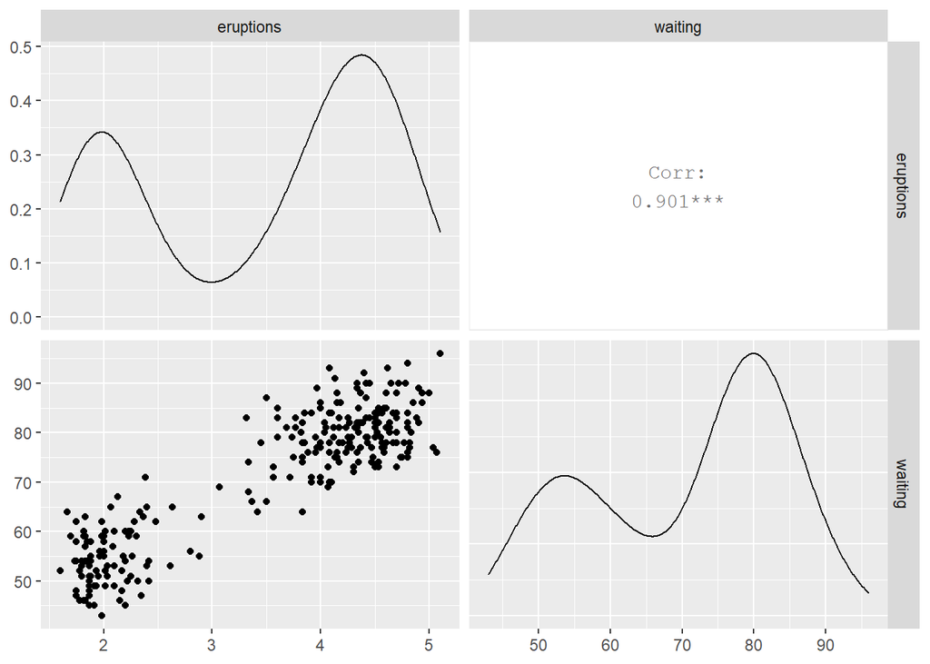

```r
ggpairs(faithful)
```